# R Notebook

import the data from the library

```r
library("MASS")
head(Cars93)
```

|  | Manufacturer | Model | Type | Min.Price | Price | Max.Price | MPG.city | MPG.highway | AirBags | DriveTrain | Cylinders | EngineSize | Horsepower | RPM | Rev.per.mile | Man.trans.avail | Fuel.tank.capacity | Passengers | Length | Wheelbase | Width | Turn.circle | Rear.seat.room | Luggage.room | Weight | Origin | Make |
| --- | --- | --- | --- | --- | --- | --- | --- | --- | --- | --- | --- | --- | --- | --- | --- | --- | --- | --- | --- | --- | --- | --- | --- | --- | --- | --- | --- |
| 1 | Acura | Integra | Small | 12.9 | 15.9 | 18.8 | 25 | 31 | None | Front | 4 | 1.8 | 140 | 6300 | 2890 | Yes | 13.2 | 5 | 177 | 102 | 68 | 37 | 26.5 | 11 | 2705 | non-USA | Acura Integra |
| 2 | Acura | Legend | Midsize | 29.2 | 33.9 | 38.7 | 18 | 25 | Driver & Passenger | Front | 6 | 3.2 | 200 | 5500 | 2335 | Yes | 18.0 | 5 | 195 | 115 | 71 | 38 | 30.0 | 15 | 3560 | non-USA | Acura Legend |
| 3 | Audi | 90 | Compact | 25.9 | 29.1 | 32.3 | 20 | 26 | Driver only | Front | 6 | 2.8 | 172 | 5500 | 2280 | Yes | 16.9 | 5 | 180 | 102 | 67 | 37 | 28.0 | 14 | 3375 | non-USA | Audi 90 |
| 4 | Audi | 100 | Midsize | 30.8 | 37.7 | 44.6 | 19 | 26 | Driver & Passenger | Front | 6 | 2.8 | 172 | 5500 | 2535 | Yes | 21.1 | 6 | 193 | 106 | 70 | 37 | 31.0 | 17 | 3405 | non-USA | Audi 100 |
| 5 | BMW | 535i | Midsize | 23.7 | 30.0 | 36.2 | 22 | 30 | Driver only | Rear | 4 | 3.5 | 208 | 5700 | 2545 | Yes | 21.1 | 4 | 186 | 109 | 69 | 39 | 27.0 | 13 | 3640 | non-USA | BMW 535i |
| 6 | Buick | Century | Midsize | 14.2 | 15.7 | 17.3 | 22 | 31 | Driver only | Front | 4 | 2.2 | 110 | 5200 | 2565 | No | 16.4 | 6 | 189 | 105 | 69 | 41 | 28.0 | 16 | 2880 | USA | Buick Century |

*Histograms* for Cars’ price and 93 Models of 1993 Cars

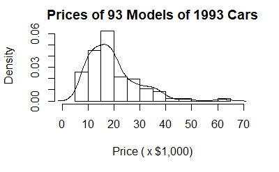

```r
hist(Cars93$Price,xlab ="Price ( x $1,000)" , xlim = c(0,70),main =
"Prices of 93 Models of 1993 Cars",probability = TRUE)
lines(density(Cars93$Price))
```

*table*, illurstrating the types and frequencies of cars. First, make a kind of table which can use ‘barplot()’

```r
table(Cars93$Type)
```

```
Compact   Large Midsize   Small  Sporty     Van
     16      11      22      21      14       9
```

```r
#barplot(table(Cars93$Type),ylim = c(0,25),xlab = "Type",ylab = "Frequency",
 #       axis.lty = "Solid",space = .05)
```

*Pie graphs* , this type of graph couldn’t be more strightforward.

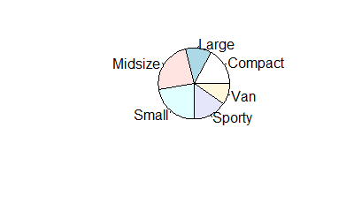

```r
pie(table(Cars93$Type))
```

*doc charts*, This is one of those infrequent cases where the independent varibale is on the y-axis and the dependent variable is on the x-axis. let’s first create the necessary vectors, chich turn the table into a data frame:

```r
type.frame <- data.frame(table(Cars93$Type))
type.frame
```

| Var1 | Freq |
| --- | --- |
| Compact | 16 |
| Large | 11 |
| Midsize | 22 |
| Small | 21 |
| Sporty | 14 |
| Van | 9 |

After you have the data frame, this line produces the doc chart:

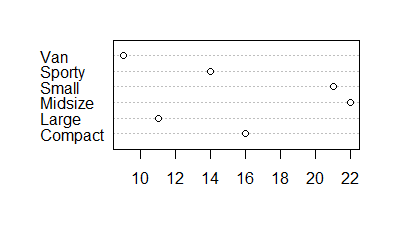

```r
dotchart(type.frame$Freq,type.frame$Var1)
```

### Bar plots revisted

If the dependent variable is a data point rather than a frequency, this impress us to think about a data visualizing that reveal of those data. let’s first create a vector of the values in the cells:

```r
#create a vector of the values in the cells
rev.values <- c(1000,1300,1300,1100,1400,800,1200,1500,
                1850,2330,860,1300,1400,1600,1970,570,380,
                450,465,580,155,190,210,250,300)
```

Then, turns this vector into a matrix.

```r
space.rev <- matrix(rev.values,nrow = 5,byrow = T)
```

Finally, supply column names and row names to the matrix:

```r
colnames(space.rev)<- c("1990","1991","1992","1993","1994")
rownames(space.rev) <- c("Commercial Satellites Delivered",
                         "Satellite Services","satellite Ground Equipment",
                         "Commercial Launches","Remote Sensing Data")
space.rev
```

```
                                1990 1991 1992 1993 1994
Commercial Satellites Delivered 1000 1300 1300 1100 1400
Satellite Services               800 1200 1500 1850 2330
satellite Ground Equipment       860 1300 1400 1600 1970
Commercial Launches              570  380  450  465  580
Remote Sensing Data              155  190  210  250  300
```

create a vector of colors for the bars:

```r
color.names = c("black","grey25","grey50","grey75","white")
```

And now for the plot:

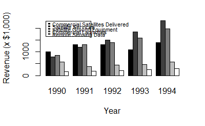

```r
barplot(space.rev,beside = T,xlab = "Year",ylab = "Revenue (x $1,000)",col = color.names)
#add legend.
legend(1,2300,rownames(space.rev),cex = .7,fill = color.names,bty = "n ")
```

### Scatter plots

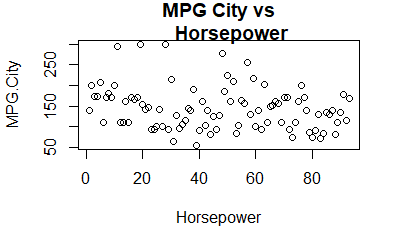

```r
plot(Cars93$Horsepower,Cars93$MPG.City,xlab = "Horsepower",ylab = "MPG.City",main = "MPG City vs
     Horsepower")
```

Alternative way for declaring ,*~* means depends on the following variable.

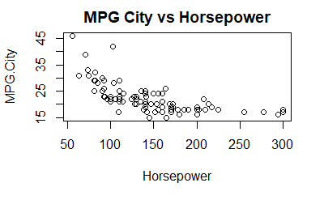

```r
plot(MPG.city ~ Horsepower,data = Cars93,xlab = "Horsepower",ylab = "MPG.City",
     main = "MPG City vs Horsepower")
```

### A plot twist

R enable you to change the symbol that depicts the points in the graph. For default, the symbol is an empty circle. To change the symbol, which is called the plottiung charecter, set the argument *pch*. R has a set of build-in numberical values *(0-25)* for *pch* that correspond to a set of symbols. The values *0-15* correspond to unfilled spaces, and *16-25* are filled. The default value is *1*. To change the plotting character to squeares, set *pch* to *0*. For **Triangle**, it’s *2*, and for filled circles it’s *16*:

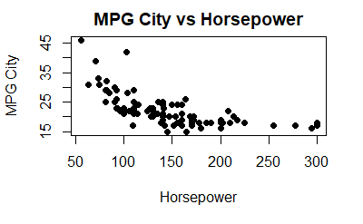

```r
#the charecters are filled circles.
plot(Cars93$Horsepower,Cars93$MPG.city,xlab = "Horsepower",ylab = "MPG City",main =
       "MPG City vs Horsepower",pch = 16)
```

We’re not limited to the build-in numberical values for *pch*. Here, for example, is an interesting touch: we can draw each point in the plot as the number of *cylinders* in the corresponding car, rather than as a symbol. Need to notice that pass to *pch* is a character rather than a number. Then, to force the Cylinders-value to be character, apply ‘as.character()’ to *Cars93$Cylinders*:

```r
pch.chara = as.character(Cars93$Cylinders)
```

and the ‘plot()’ function is

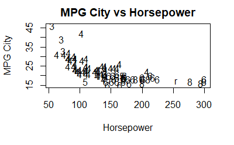

```r
plot(Cars93$Horsepower,Cars93$MPG.city,xlab = "Horsepower",ylab = "MPG City",main =
       "MPG City vs Horsepower",pch = pch.chara)
```

### Sctter plot matrix

R priovides a nice way to visualizing relationships among more than two variables. The R function for plotting this funciton works with numberical columns from a matrix or a data frame.For convenience, create a data frame that’s a subset of the *Car93* data frame. This data frame consists of just the three variables to plot. The function ‘subset()’ handles that nicely.

```r
cars.subset <- subset(Cars93,select = c(MPG.city,Price,Horsepower))
head(cars.subset)
```

|  | MPG.city | Price | Horsepower |
| --- | --- | --- | --- |
| 1 | 25 | 15.9 | 140 |
| 2 | 18 | 33.9 | 200 |
| 3 | 20 | 29.1 | 172 |
| 4 | 19 | 37.7 | 172 |
| 5 | 22 | 30.0 | 208 |
| 6 | 22 | 15.7 | 110 |

‘subset()’ has created a vector of exactly what to select out of *Car93*. And now, use ‘pair()’ function to see the visualizing.

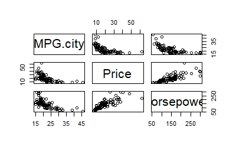

```r
pairs(cars.subset)
```

### Gradeating to ggplot2

The Base R graphice toolset will get start, but it doesn’t shine at visualization, it’s a good idea to learn *ggplot2*. Create by R-megastar Hadley Wickham, the *‘gg’* in the package name stands for “Grammar of graphics” and that’s a good indicator of what’s ahead. So a *“grammar of graphics”* is a set of rules for combining graphics components to produce graphs. Wilkinson proposed that all graphs have underlying common components – like data, a coordinate system (the x- and y- axis you know so well, for example), statistical transformaitons (like frequency counts), and objects within the graph (e.g., dots, bars, lines, or pie slices), to name a few.

#### Histograms

A graph starts with *ggplot()*, which takes two arguments. The first argument is the source of the data. The second argument maps the data components of interest into components of the graph. The function that doese the job is *aes()*. To begin a histogram for *price* in *Cars93*, the function is

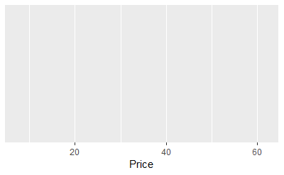

```r
library("ggplot2")
ggplot(Cars93,aes(x = Price))
```

The *aes()* function associates *Price* with the x-axis. In ggplot-world, this is called an *aesthetic mapping*. In fact, each arguments to *aes()* is called an *aesthtic*.

And what about that histogram? How do you put it into this blank grid? You have to add something indicating that you want to plot a histogram and let R take care of the rest. What you add is a **geom** function (“Geom” is short for “geometric object”). How do we add **geom_histogram()** to *ggplot()*? With a plus sign:

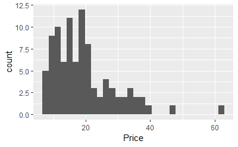

```r
ggplot(Cars93,aes(x = Price)) + geom_histogram()
```

This produces above Figure. The grammar rules tell ggplot2 that when the geometric object is a histogram is a histogram, R does the necessary calculations on the data and produces the appropriate plot.

We can customize about the ggplot. Let’s modify the graph. Each bar is called *bin*, and by default, ggplot() uses 30 of them. After ploting the histogram, *ggplot()* displays an onscreen message that advises experimenting with *binwidth* (which, unsurprisingly, specifies the width of each bin) to change the graph’s appearance. Accordingly, we use *binwidth = 5* as an argumentin *geom_histogram()*. With another function, *labs()*, we modify the labels for the axes and supply a title for the graph.

Altogether now:

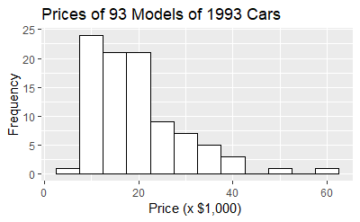

```r
ggplot(Cars93,aes(x = Price)) + geom_histogram(binwidth = 5,color = "black",fill = "white")+
  labs(x = "Price (x $1,000) " ,y = "Frequency" , title = "Prices of 93 Models of 1993 Cars")
```

#### Bar plots

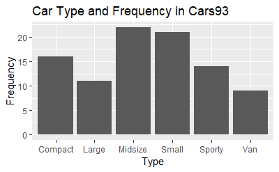

```r
ggplot(Cars93,aes(x = Type)) + geom_bar()+ labs(y = "Frequency" , title= "Car Type and Frequency in Cars93")
```

#### Doc charts

Making a doc chart begins much the same as in the base R: create a table for Type, and turn the table into a data frame.

```r
type.frame <- data.frame(table(Cars93$Type))
```

To ensure that have meaningful variable names for the aesthetic mapping, apply the *colnames()* function to name the columns in the data frame.

```r
colnames(type.frame) <- c("Type","Frequency")
type.frame
```

| Type | Frequency |
| --- | --- |
| Compact | 16 |
| Large | 11 |
| Midsize | 22 |
| Small | 21 |
| Sporty | 14 |
| Van | 9 |

On the graph. To orient the doc chart, map *Frequency* variable is on the x-axis and *Type* to the y-axis:

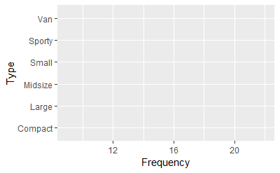

```r
ggplot(type.frame , aes(x = Frequency , y = Type))
```

The *geom* function for the doc chart is *geom_point()* is available. So this code:

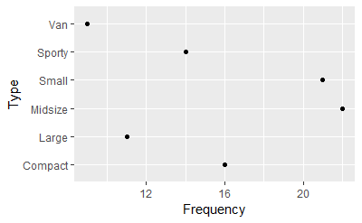

```r
ggplot(type.frame, aes(x = Frequency , y = Type)) + geom_point()
```

A couple of modifications are in order. First, with a graph like this, it’s a nice touch to rearrange the categories on the y-axis with respect to how they order on what you’re measuring on the x-axis. That necessitates a slight change in the aesthetic mapping to the y-axis:

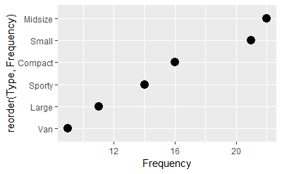

```r
ggplot(type.frame,aes(x = Frequency,y = reorder(Type,Frequency))) + geom_point(size = 4)
```

```r
# Large dots would make the chart look a little nicer
```

Additional function modify the graph’s overall appearance. One family of these functions is called *themes*. One member of this family, *theme_bw()*, removes the gray background. Adding *theme()* with appropriate a) removes the vertical lines in the grid and b) blackens the horizontal lines and makes them dotted:

```r
theme_bw() +
  theme(panel.grid.major.x = element_blank(),
        panel.grid.major.y = element_line(color = "black",
                                          linetype = "dotted"))
```

Finally, *lab()* changes the y-axis label:

```r
labs(y = "Type")
```

```
$`y`
[1] "Type"

attr(,"class")
[1] "labels"
```

without the change, the y-axis label would be “reorder(Tpye,Frequency)”. Though picturesque, that label makes little sense to the average viewer.

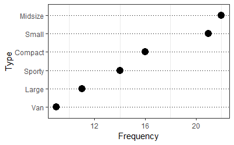

```r
ggplot(type.frame,aes(x =Frequency, y = reorder(Type,Frequency)))+
  geom_point(size = 4) + theme_bw()+
    theme(panel.grid.major.x = element_blank(),
        panel.grid.major.y = element_line(color = "black",
                                          linetype = "dotted")) + labs(y = "Type")
```

#### Bar plots re-revisited

Use *ggplot()* to create one from *space.rev*, the data set I created from the data.

The function *melt()* turns wides format into long. Another function, *cast()*, does the reverse. These functions are a huge help because they eliminate the need to go schlepping around in spreadsheets to reshape a data set. So, with *reshape2* in the library.

```r
library("reshape2")
space.melt <- melt(space.rev)
```

So, that’s really all there is to it.

```r
# look at those first few rows
head(space.melt)
```

|  | Var1 | Var2 | value |
| --- | --- | --- | --- |
| 1 | Commercial Satellites Delivered | 1990 | 1000 |
| 2 | Satellite Services | 1990 | 800 |
| 3 | satellite Ground Equipment | 1990 | 860 |
| 4 | Commercial Launches | 1990 | 570 |
| 5 | Remote Sensing Data | 1990 | 155 |
| 6 | Commercial Satellites Delivered | 1991 | 1300 |

Next, give meaningful names to the columns:

```r
colnames(space.melt) <- c("Industry","Year","Revenue")
head(space.melt)
```

|  | Industry | Year | Revenue |
| --- | --- | --- | --- |
| 1 | Commercial Satellites Delivered | 1990 | 1000 |
| 2 | Satellite Services | 1990 | 800 |
| 3 | satellite Ground Equipment | 1990 | 860 |
| 4 | Commercial Launches | 1990 | 570 |
| 5 | Remote Sensing Data | 1990 | 155 |
| 6 | Commercial Satellites Delivered | 1991 | 1300 |

And now we are ready to roll. Start with *ggplot()*. The aesthetic mappings are strightforward:

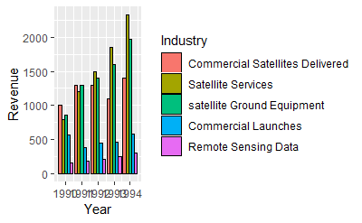

```r
ggplot(space.melt,aes(x = Year,y= Revenue,fill = Industry)) +
  geom_bar(stat = "identity",position = "dodge" , color = "black")
```

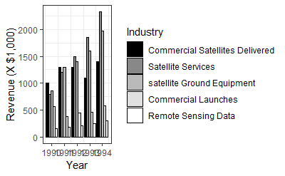

```r
ggplot(space.melt , aes(x = Year, y = Revenue, fill = Industry)) + geom_bar(stat = "identity",position = "dodge",color = "black")+
  scale_fill_grey(start = 0,end = 1)+
  labs( y = "Revenue (X $1,000)")+
  theme_bw()+
  theme(panel.grid.major.x = element_blank())
```

#### Scatter plots

A scatter plot is a great way to show the relationship between two variables, liks horsepower and miles per gallon for city driving. And *ggplot()* is a great way to draw the scatter plot. The grammar of this will be easy:

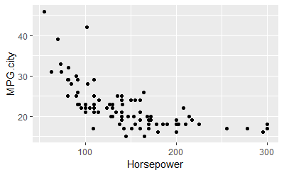

```r
ggplot(Cars93,aes (x = Horsepower, y = MPG.city)) + geom_point()
```

Instead, each point is the number of cylinders, which is a label that appears as a text character. First, we need and additional *aesthetic* mapping in *aes()*. That mapping is **label**, and set it to Cylinders:

```r
ggplot(Cars93, aes(x = Horsepower,y = MPG.city , label = Cylinders))+ geom_point()
```

[output not shown]

Use the theme functions to make the graph’s appearance look like the one showning as before. As in the doc chart example, *theme_bw()* eliminates the gray background. The *theme()* function eliminates the grid:

```r
#theme(panle.grid = element_blank())
```

*element_black()* is a function that draws a blank element. Altogether:

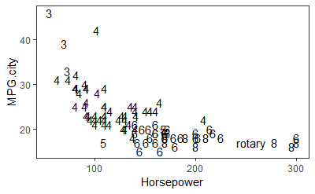

```r
ggplot(Cars93,aes(x = Horsepower, y = MPG.city, label = Cylinders)) + geom_text() + theme_bw()+
  theme(panel.grid = element_blank())
```

#### Scatter plot matrix

The ggplot2 package had a function called *plotparis()* that did something similar, but not anymore. GGally, a package build on ggplot2, provides *ggparis()* to draw scatter plot matries, and it does this in a flaboyant way.

The GGally package isn’t on the package tab. We have to selesct Install and type **GGally** in the Install Package dialog box. When it appears on the Packages tab, click the check box next to it.

Or we can type **install.package(“*name of the package*”)** in the console for installing/collecting this package.

```r
install.packages("GGally")
```

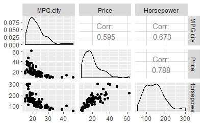

```r
library("GGally")
ggpairs(cars.subset)
```

As showing, this one’s a beauty. The cells along the main diagonal present density plots of the variables.

The three scatter plots are in the cells below the main diagonal. Rather than show the same scatter plots with the axes reversed in the cells above the main diagonal, each above-the-diagonal cell shows a *correlation coefficient* that summarize the relationship between the cell’s row variable and its column variable.

[figure not shown]

#### Box plots

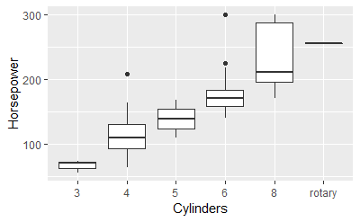

```r
ggplot(Cars93,aes(x= Cylinders , y = Horsepower)) +
  geom_boxplot()
```

```r
ggplot(Cars93,aes(x = Cylinders , y = Horsepower)) + geom_boxplot()+ geom_point()
```

[output not shown]

There are mand points overlap, graphics gurus refer to this as *overploting*. One way to deal with overplotting is to randomly reposition the points so as to reveal them but not change what they represent. This is called *jittering*. And ggplot2 has a *geom* function for that: *geom_jitter()*. Adding this function to the code:

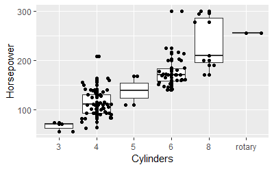

```r
ggplot(Cars93,aes(x = Cylinders , y = Horsepower)) + geom_boxplot()+ geom_point()+
  geom_jitter()
```